# Project_Ensemble_Techniques_MAILLON_Remi

#### Impact of pitch satisfaction score on purchase

```
ProdTaken                  0    1   All
PitchSatisfactionScore
1                        798  144   942
2                        498   88   586
3                       1162  316  1478
4                        750  162   912
5                        760  210   970
All                     3968  920  4888
------------------------------------------------------------------------------------------------------------------------
```

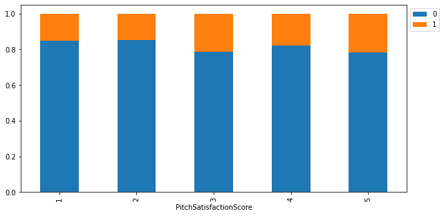

```python
stacked_plot(data['PitchSatisfactionScore'])
```

- The proportion of customers purchasing the product is lower for low pitch satisfaction scores.

#### Impact of car owning on purchase

```
ProdTaken     0    1   All
OwnCar
0          1496  360  1856
1          2472  560  3032
All        3968  920  4888
------------------------------------------------------------------------------------------------------------------------
```

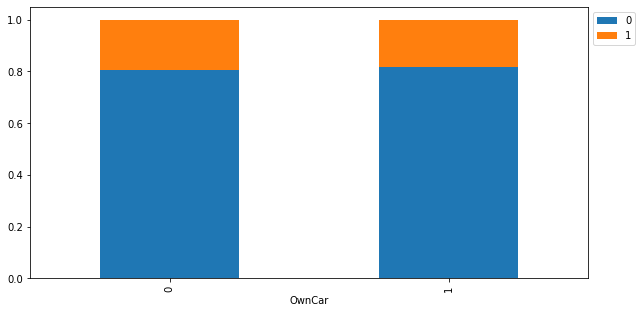

```python
stacked_plot(data['OwnCar'])
```

- The impact of this variable is not significant.

#### Impact of Number of children visited on purchase

```
ProdTaken                   0    1   All
NumberOfChildrenVisited
0.0                       880  202  1082
1.0                      1747  399  2146
2.0                      1082  253  1335
3.0                       259   66   325
All                      3968  920  4888
------------------------------------------------------------------------------------------------------------------------
```

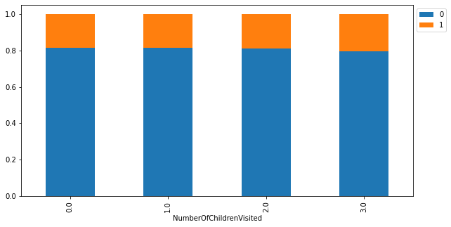

```python
stacked_plot(data['NumberOfChildrenVisited'])
```

- The impact of this variable is not really significant

#### Impact of product pitched on purchase

```
ProdTaken          0    1   All
ProductPitched
Deluxe           322   20   342
King             210   20   230
Multi           1290  552  1842
Standard         618  124   742
Super Deluxe    1528  204  1732
All             3968  920  4888
------------------------------------------------------------------------------------------------------------------------
```

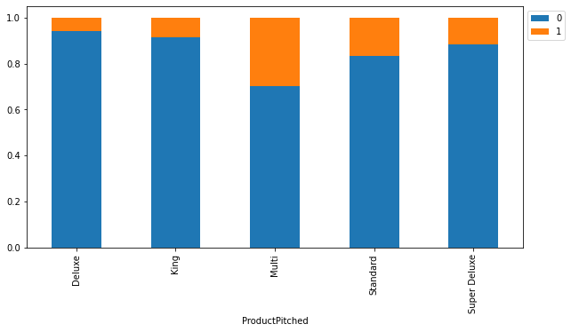

```python
stacked_plot(data['ProductPitched'])
```

- The proportion of customers purchasing the product is greater among the multi and standard packages

#### Impact of marital status on purchase

```
ProdTaken         0    1   All
MaritalStatus
Divorced        826  124   950
Married        2014  326  2340
Single          612  304   916
Unmarried       516  166   682
All            3968  920  4888
------------------------------------------------------------------------------------------------------------------------
```

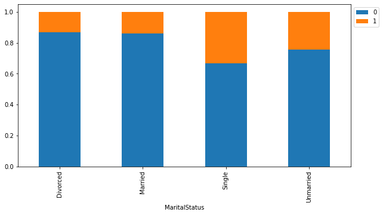

```python
stacked_plot(data['MaritalStatus'])
```

- The proportion of customers purchasing the products is greater among single or unmarried people

#### Impact of designation on purchase

```
ProdTaken          0    1   All
Designation
AVP              322   20   342
Executive       1290  552  1842
Manager         1528  204  1732
Senior Manager   618  124   742
VP               210   20   230
All             3968  920  4888
------------------------------------------------------------------------------------------------------------------------
```

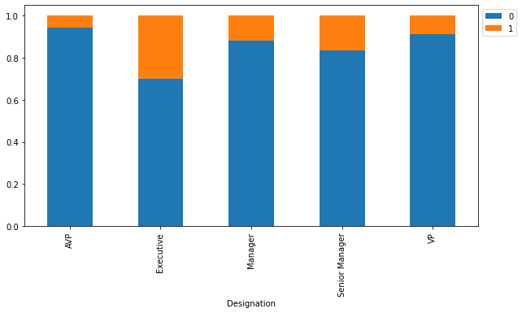

```python
stacked_plot(data['Designation'])
```

- The proportion of customers purchasing the product is greater among executives

#### Impact of Preferred login device on purchase

```
ProdTaken                0    1   All
PreferredLoginDevice
Company Invited       1109  310  1419
Self Enquiry          2837  607  3444
All                   3946  917  4863
------------------------------------------------------------------------------------------------------------------------
```

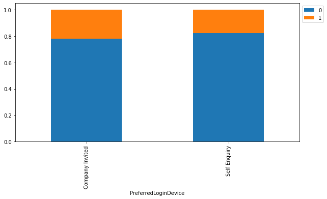

```python
stacked_plot(data['PreferredLoginDevice'])
```

- The proportion of customers purchasing the product is greater among customers invited by a company than self enquiry.

#### Impact of occupation on purchase

```
ProdTaken          0    1   All
Occupation
Free Lancer        0    2     2
Large Business   314  120   434
Salaried        1954  414  2368
Small Business  1700  384  2084
All             3968  920  4888
------------------------------------------------------------------------------------------------------------------------
```

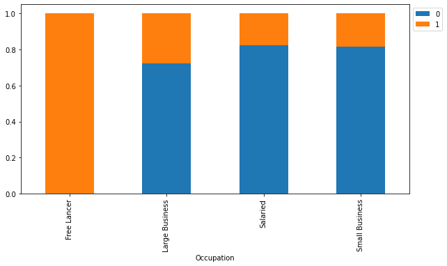

```python
stacked_plot(data['Occupation'])
```

- The very small numbers of free lancers (only 2) is not enough to draw any firm conclusions regarding this specific category.
- However, there is greater proportion of customers purchasing the product among people managing large businesses rather than small businesses or salaried.

```python
data.groupby('Designation').mean()[['MonthlyIncome']]
```

[output not shown]

## Data preprocessing

Prepare the data for analysis - Missing value Treatment, Outlier Detection(treat, if needed- why or why not ), Feature Engineering, Prepare data for modeling

### Missing value Treatment

- Some columns have null values.

```python
data.isnull().sum().sort_values(ascending=False).to_frame('Missing values')
```

|  | Missing values |
| --- | --- |
| DurationOfPitch | 251 |
| MonthlyIncome | 233 |
| Age | 226 |
| NumberOfTrips | 140 |
| NumberOfChildrenVisited | 66 |
| NumberOfFollowups | 45 |
| PreferredPropertyStar | 26 |
| PreferredLoginDevice | 25 |
| Designation | 0 |
| OwnCar | 0 |
| PitchSatisfactionScore | 0 |
| Passport | 0 |
| ProdTaken | 0 |
| MaritalStatus | 0 |
| NumberOfPersonVisited | 0 |
| Gender | 0 |
| Occupation | 0 |
| CityTier | 0 |
| ProductPitched | 0 |

Replacing null values with mean for numerical variables and unknown for categorical variables:

```python
for feature in data.columns:
    if data[feature].dtype == 'object':
        data[feature].fillna('unknown', inplace=True)
    else:
        data[feature].fillna(int(data[feature].mean()), inplace=True)
```

### Converting object data types into categorical variables in order to reduce memory usage.

```python
for feature in data.columns:
    if data[feature].dtype == 'object':
        data[feature] = data[feature].astype("category")
```

```python
data.info()
```

```
<class 'pandas.core.frame.DataFrame'>
RangeIndex: 4888 entries, 0 to 4887
Data columns (total 19 columns):
 #   Column                   Non-Null Count  Dtype
---  ------                   --------------  -----
 0   ProdTaken                4888 non-null   int64
 1   Age                      4888 non-null   float64
 2   PreferredLoginDevice     4888 non-null   category
 3   CityTier                 4888 non-null   int64
 4   DurationOfPitch          4888 non-null   float64
 5   Occupation               4888 non-null   category
 6   Gender                   4888 non-null   category
 7   NumberOfPersonVisited    4888 non-null   int64
 8   NumberOfFollowups        4888 non-null   float64
 9   ProductPitched           4888 non-null   category
 10  PreferredPropertyStar    4888 non-null   float64
 11  MaritalStatus            4888 non-null   category
 12  NumberOfTrips            4888 non-null   float64
 13  Passport                 4888 non-null   int64
 14  PitchSatisfactionScore   4888 non-null   int64
 15  OwnCar                   4888 non-null   int64
 16  NumberOfChildrenVisited  4888 non-null   float64
 17  Designation              4888 non-null   category
 18  MonthlyIncome            4888 non-null   float64
dtypes: category(6), float64(7), int64(6)
memory usage: 526.3 KB
```

```python
for feature in data.columns:
    if pd.api.types.is_categorical_dtype(data[feature]):
        print(data[feature].value_counts(), '\n')
```

```
Self Enquiry       3444
Company Invited    1419
unknown              25
Name: PreferredLoginDevice, dtype: int64

Salaried          2368
Small Business    2084
Large Business     434
Free Lancer          2
Name: Occupation, dtype: int64

Male      2916
Female    1972
Name: Gender, dtype: int64

Multi           1842
Super Deluxe    1732
Standard         742
Deluxe           342
King             230
Name: ProductPitched, dtype: int64

Married      2340
Divorced      950
Single        916
Unmarried     682
Name: MaritalStatus, dtype: int64

Executive         1842
Manager           1732
Senior Manager     742
AVP                342
VP                 230
Name: Designation, dtype: int64
```

### Label encoding for categorical variables

- One hot label encoding for gender variable (male vs female)
- Other categorical variables have been replaced as follows:

```python
replaceStruct = {
                'PreferredLoginDevice': {"unknown": 1, "Self Enquiry": 2 ,"Company Invited": 3},
                'ProductPitched': {"Multi": 1, "Standard": 2 , "Super Deluxe": 3, 'King': 4, 'Deluxe': 5},
                'Designation': {'Executive': 1, 'Senior Manager': 2, 'Manager': 3, 'VP': 4, 'AVP': 5},
                'Occupation': {'Free Lancer': 1, 'Large Business': 2, 'Small Business': 3, 'Salaried': 4},
                'MaritalStatus': {'Single': 1, 'Unmarried': 2, 'Married': 3, 'Divorced': 4}
                    }

oneHotCols = ['Gender']
```

```python
data=data.replace(replaceStruct)
data=pd.get_dummies(data, columns=oneHotCols, drop_first=True)
data.head(10)
```

|  | ProdTaken | Age | PreferredLoginDevice | CityTier | DurationOfPitch | Occupation | NumberOfPersonVisited | NumberOfFollowups | ProductPitched | PreferredPropertyStar | MaritalStatus | NumberOfTrips | Passport | PitchSatisfactionScore | OwnCar | NumberOfChildrenVisited | Designation | MonthlyIncome | Gender_Male |
| --- | --- | --- | --- | --- | --- | --- | --- | --- | --- | --- | --- | --- | --- | --- | --- | --- | --- | --- | --- |
| 0 | 1 | 41.0 | 2 | 3 | 6.0 | 4 | 3 | 3.0 | 3 | 3.0 | 1 | 1.0 | 1 | 2 | 1 | 0.0 | 3 | 20993.0 | 0 |
| 1 | 0 | 49.0 | 3 | 1 | 14.0 | 4 | 3 | 4.0 | 3 | 4.0 | 4 | 2.0 | 0 | 3 | 1 | 2.0 | 3 | 20130.0 | 1 |
| 2 | 1 | 37.0 | 2 | 1 | 8.0 | 1 | 3 | 4.0 | 1 | 3.0 | 1 | 7.0 | 1 | 3 | 0 | 0.0 | 1 | 17090.0 | 1 |
| 3 | 0 | 33.0 | 3 | 1 | 9.0 | 4 | 2 | 3.0 | 1 | 3.0 | 4 | 2.0 | 1 | 5 | 1 | 1.0 | 1 | 17909.0 | 0 |
| 4 | 0 | 37.0 | 2 | 1 | 8.0 | 3 | 2 | 3.0 | 1 | 4.0 | 4 | 1.0 | 0 | 5 | 1 | 0.0 | 1 | 18468.0 | 1 |
| 5 | 0 | 32.0 | 3 | 1 | 8.0 | 4 | 3 | 3.0 | 1 | 3.0 | 1 | 1.0 | 0 | 5 | 1 | 1.0 | 1 | 18068.0 | 1 |
| 6 | 0 | 59.0 | 2 | 1 | 9.0 | 3 | 2 | 2.0 | 1 | 5.0 | 4 | 5.0 | 1 | 2 | 1 | 1.0 | 1 | 17670.0 | 0 |
| 7 | 0 | 30.0 | 2 | 1 | 30.0 | 4 | 3 | 3.0 | 1 | 3.0 | 3 | 2.0 | 0 | 2 | 0 | 1.0 | 1 | 17693.0 | 1 |
| 8 | 0 | 38.0 | 3 | 1 | 29.0 | 4 | 2 | 4.0 | 2 | 3.0 | 2 | 1.0 | 0 | 3 | 0 | 0.0 | 2 | 24526.0 | 1 |
| 9 | 0 | 36.0 | 2 | 1 | 33.0 | 3 | 3 | 3.0 | 3 | 3.0 | 4 | 7.0 | 0 | 3 | 1 | 0.0 | 3 | 20237.0 | 1 |

### Treatment of outliers

Although we have already identified outliers in the number of trips, duration of pitch and monthly income columns, it is not necessary to treat them as the impact of outliers on decision trees type algorithms is negligible.

### Split the data into train and test sets

```python
X = data.drop("ProdTaken" , axis=1)
y = data["ProdTaken"]
```

```python
X_train, X_test, y_train, y_test = train_test_split(X, y, test_size=.30, random_state=3, stratify=y)
```

- 70% / 30% split of data set for model training and testing respectively.
- Because the target variables is imbalance (81.2 % customers not taking product vs 18.8 % taking product), stratification is required in the split.

## Model building - Bagging

Build Decision tree, bagging classifier and random forest.

### Model performance evaluation

- If the model fails to detect the customers purchasing the product (False Negative), the company will lose money.
- If the model predicts incorrectly the customers not purchasing the product (False Positive), the marketing team will have wasted its efforts in targeting the wrong customer.
- However, the greater loss for the company would be if the model fails to detect the potential customers purchasing the product. Therefore the emphasis should be put on reducing the number of False Negative, hence maximizing the recall.

Before building the model, let's create functions to calculate recall on train/test sets and plot the confusion matrix

```python
## Function to create confusion matrix
def make_confusion_matrix(model,y_actual,labels=[1, 0]):
    '''
    model : classifier to predict values of X
    y_actual : ground truth

    '''
    y_predict = model.predict(X_test)
    cm=metrics.confusion_matrix( y_actual, y_predict, labels=[0, 1])
    df_cm = pd.DataFrame(cm, index = [i for i in ["Actual - No","Actual - Yes"]],
                  columns = [i for i in ['Predicted - No','Predicted - Yes']])
    group_counts = ["{0:0.0f}".format(value) for value in
                cm.flatten()]
    group_percentages = ["{0:.2%}".format(value) for value in
                         cm.flatten()/np.sum(cm)]
    labels = [f"{v1}\n{v2}" for v1, v2 in
              zip(group_counts,group_percentages)]
    labels = np.asarray(labels).reshape(2,2)
    plt.figure(figsize = (10,7))
    sns.heatmap(df_cm, annot=labels,fmt='')
    plt.ylabel('True label')
    plt.xlabel('Predicted label')
```

```python
##  Function to calculate recall score
def get_recall_score(model,flag=True):
    '''
    model : classifier to predict values of X

    '''
    # defining an empty list to store train and test results
    score_list=[]

    #Predicting on train and tests
    pred_train = model.predict(X_train)
    pred_test = model.predict(X_test)

    #Recall of the model
    train_recall = metrics.recall_score(y_train,pred_train)
    test_recall = metrics.recall_score(y_test,pred_test)

    score_list.extend((train_recall,test_recall))

    # If the flag is set to True then only the following print statements will be dispayed. The default value is set to True.
    if flag == True:
        print("Recall on training set : ",metrics.recall_score(y_train,pred_train))
        print("Recall on test set : ",metrics.recall_score(y_test,pred_test))

    else:
        return score_list # returning the list with train and test scores
```

### Decision tree without tuning

```python
dTree = tree.DecisionTreeClassifier(random_state=3, class_weight='balanced')
dTree.fit(X_train, y_train)
```

```
DecisionTreeClassifier(ccp_alpha=0.0, class_weight='balanced', criterion='gini',
                       max_depth=None, max_features=None, max_leaf_nodes=None,
                       min_impurity_decrease=0.0, min_impurity_split=None,
                       min_samples_leaf=1, min_samples_split=2,
                       min_weight_fraction_leaf=0.0, presort='deprecated',
                       random_state=3, splitter='best')
```

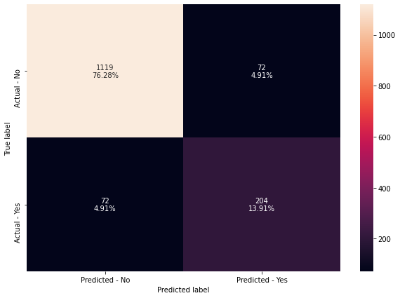

```python
make_confusion_matrix(dTree, y_test)
```

```python
get_recall_score(dTree)
```

```
Recall on training set :  1.0
Recall on test set :  0.7391304347826086
```

- In the absence of hyperparameter tuning or pruning, the tree got too complex and is subject to overfitting.

#### Feature importance

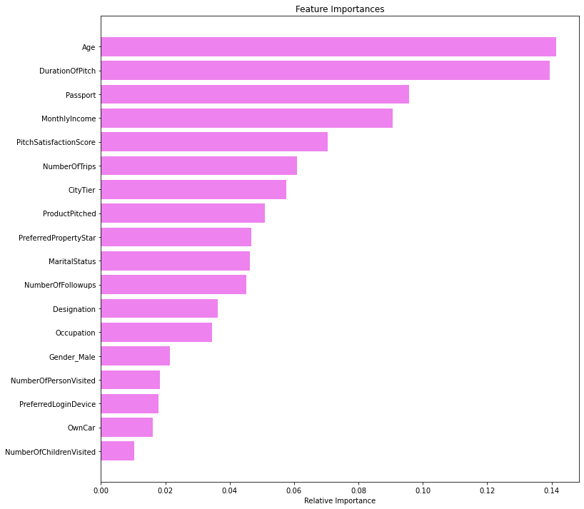

```python
importances = dTree.feature_importances_
indices = np.argsort(importances)
feature_names=list(X.columns)

plt.figure(figsize=(12,12))
plt.title('Feature Importances')
plt.barh(range(len(indices)), importances[indices], color='violet', align='center')
plt.yticks(range(len(indices)), [feature_names[i] for i in indices])
plt.xlabel('Relative Importance')
plt.show()
```

### Decision tree with hyperparameter tuning

Use grid search for hyperparameter tuning

```python
# Choose the type of classifier.
dTree_tuned = tree.DecisionTreeClassifier(random_state=3, class_weight='balanced')

# Grid of parameters to choose from
## add from article
parameters = {'max_depth': [3, 5, 7, 10, 15],
              'max_leaf_nodes': [8, 32, 64, 128, 256],
              'min_samples_leaf': [1, 2, 4, 6, 8, 10],
             }

# Type of scoring used to compare parameter combinations
acc_scorer = metrics.make_scorer(metrics.recall_score)

# Run the grid search
grid_obj = GridSearchCV(dTree_tuned, parameters, scoring=acc_scorer,cv=5)
grid_obj = grid_obj.fit(X_train, y_train)

# Set the clf to the best combination of parameters
dTree_tuned = grid_obj.best_estimator_

# Fit the best algorithm to the data.
dTree_tuned.fit(X_train, y_train)
```

```
DecisionTreeClassifier(ccp_alpha=0.0, class_weight='balanced', criterion='gini',
                       max_depth=10, max_features=None, max_leaf_nodes=64,
                       min_impurity_decrease=0.0, min_impurity_split=None,
                       min_samples_leaf=8, min_samples_split=2,
                       min_weight_fraction_leaf=0.0, presort='deprecated',
                       random_state=3, splitter='best')
```

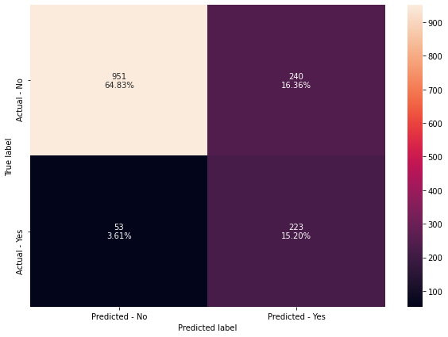

```python
make_confusion_matrix(dTree_tuned, y_test)
```

```python
# Recall on train and test
get_recall_score(dTree_tuned)
```

```
Recall on training set :  0.9145962732919255
Recall on test set :  0.8079710144927537
```

- Thanks to hyper parameter tuning, the recall score on the testing set has increased from 73.9% to 80.8%.
- The recall score on the training set has decreased thus showing that the decision tree is less prone to overfitting with the new constrains.

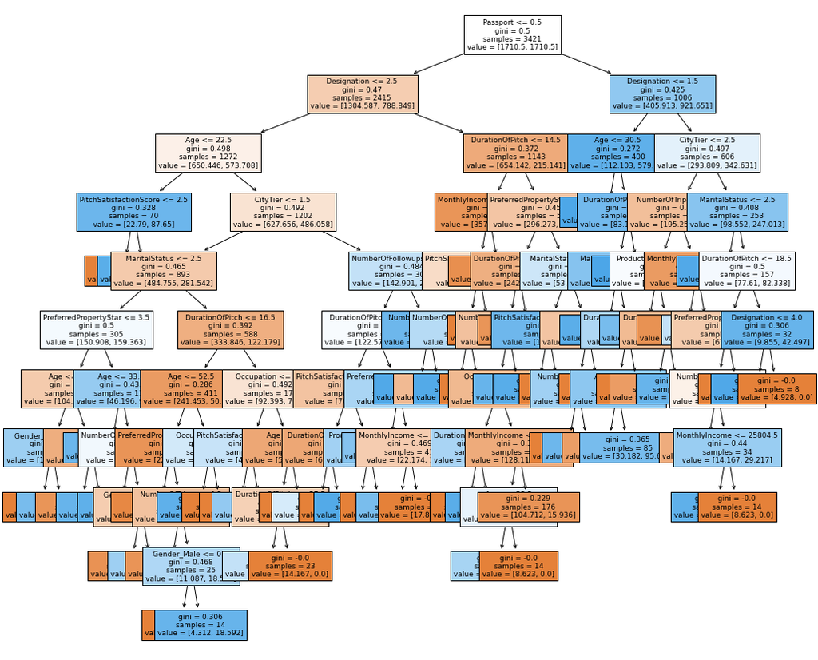

```python
plt.figure(figsize=(17,15))
tree.plot_tree(dTree_tuned,feature_names=feature_names, filled=True, fontsize=9)
plt.show()
```

#### Feature importance

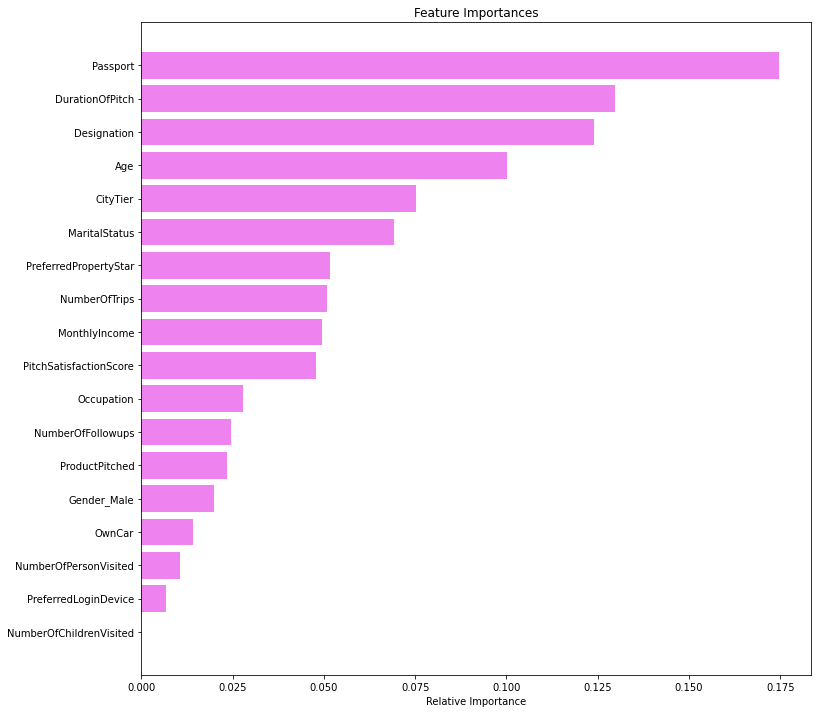

```python
importances = dTree_tuned.feature_importances_
indices = np.argsort(importances)
feature_names=list(X.columns)

plt.figure(figsize=(12,12))
plt.title('Feature Importances')
plt.barh(range(len(indices)), importances[indices], color='violet', align='center')
plt.yticks(range(len(indices)), [feature_names[i] for i in indices])
plt.xlabel('Relative Importance')
plt.show()
```

### Decision tree with Cost Complexity Pruning

```python
clf = tree.DecisionTreeClassifier(random_state=3, class_weight='balanced')
path = clf.cost_complexity_pruning_path(X_train, y_train)
ccp_alphas, impurities = path.ccp_alphas, path.impurities
```

```python
pd.DataFrame(path)
```

|  | ccp_alphas | impurities |
| --- | --- | --- |
| 0 | 0.000000 | 1.013477e-16 |
| 1 | 0.000118 | 3.549561e-04 |
| 2 | 0.000170 | 6.953237e-04 |
| 3 | 0.000170 | 1.035691e-03 |
| 4 | 0.000173 | 1.726755e-03 |
| ... | ... | ... |
| 201 | 0.007495 | 4.064791e-01 |
| 202 | 0.013763 | 4.202422e-01 |
| 203 | 0.014536 | 4.347782e-01 |
| 204 | 0.017368 | 4.521464e-01 |
| 205 | 0.047854 | 5.000000e-01 |

206 rows × 2 columns

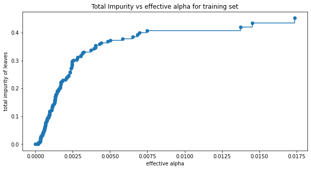

```python
fig, ax = plt.subplots(figsize=(10,5))
ax.plot(ccp_alphas[:-1], impurities[:-1], marker='o', drawstyle="steps-post")
ax.set_xlabel("effective alpha")
ax.set_ylabel("total impurity of leaves")
ax.set_title("Total Impurity vs effective alpha for training set")
plt.show()
```

```python
clfs = []
for ccp_alpha in ccp_alphas:
    clf = tree.DecisionTreeClassifier(random_state=3, class_weight='balanced', ccp_alpha=ccp_alpha)
    clf.fit(X_train, y_train)
    clfs.append(clf)
```

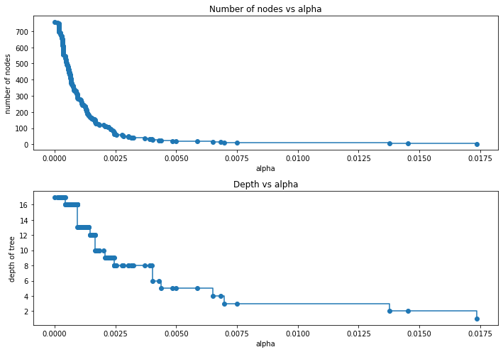

```python
clfs = clfs[:-1]
ccp_alphas = ccp_alphas[:-1]

node_counts = [clf.tree_.node_count for clf in clfs]
depth = [clf.tree_.max_depth for clf in clfs]
fig, ax = plt.subplots(2, 1,figsize=(10,7))
ax[0].plot(ccp_alphas, node_counts, marker='o', drawstyle="steps-post")
ax[0].set_xlabel("alpha")
ax[0].set_ylabel("number of nodes")
ax[0].set_title("Number of nodes vs alpha")
ax[1].plot(ccp_alphas, depth, marker='o', drawstyle="steps-post")
ax[1].set_xlabel("alpha")
ax[1].set_ylabel("depth of tree")
ax[1].set_title("Depth vs alpha")
fig.tight_layout()
```

```python
recall_train=[]
for clf in clfs:
    pred_train=clf.predict(X_train)
    values_train=metrics.recall_score(y_train,pred_train)
    recall_train.append(values_train)
```

```python
recall_test=[]
for clf in clfs:
    pred_test=clf.predict(X_test)
    values_test=metrics.recall_score(y_test,pred_test)
    recall_test.append(values_test)
```

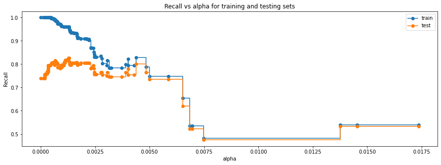

```python
fig, ax = plt.subplots(figsize=(15,5))
ax.set_xlabel("alpha")
ax.set_ylabel("Recall")
ax.set_title("Recall vs alpha for training and testing sets")
ax.plot(ccp_alphas, recall_train, marker='o', label="train",
        drawstyle="steps-post")
ax.plot(ccp_alphas, recall_test, marker='o', label="test",
        drawstyle="steps-post")
ax.legend()
plt.show()
```

```python
# creating the model where we get highest train and test recall
index_best_model = np.argmax(recall_test)
dTree_pruned = clfs[index_best_model]
print(dTree_pruned)
```

```
DecisionTreeClassifier(ccp_alpha=0.001272418548876897, class_weight='balanced',
                       criterion='gini', max_depth=None, max_features=None,
                       max_leaf_nodes=None, min_impurity_decrease=0.0,
                       min_impurity_split=None, min_samples_leaf=1,
                       min_samples_split=2, min_weight_fraction_leaf=0.0,
                       presort='deprecated', random_state=3, splitter='best')
```

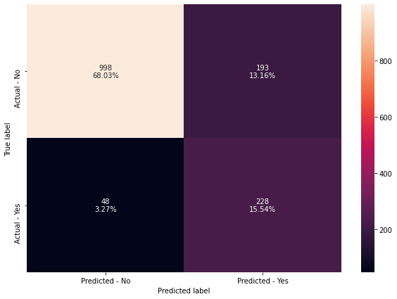

```python
make_confusion_matrix(dTree_pruned, y_test)
```

```python
# Recall on train and test
get_recall_score(dTree_pruned)
```

```
Recall on training set :  0.9596273291925466
Recall on test set :  0.8260869565217391
```

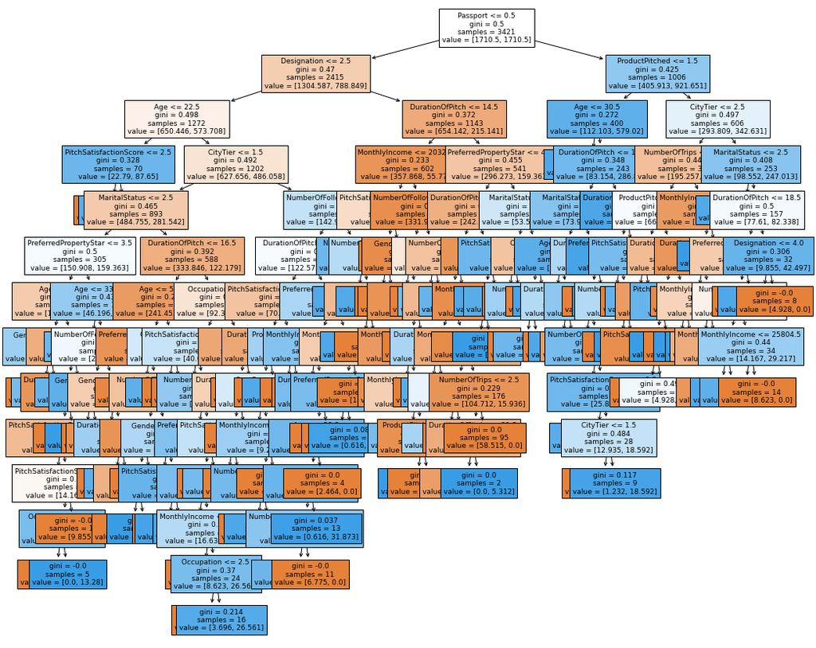

```python
plt.figure(figsize=(17,15))
tree.plot_tree(dTree_pruned,feature_names=feature_names, filled=True, fontsize=9)
plt.show()
```

#### Feature importance

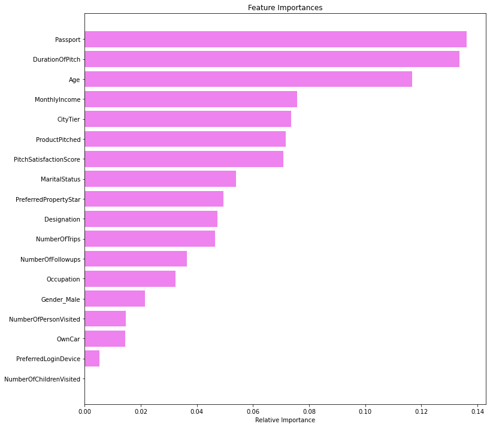

```python
importances = dTree_pruned.feature_importances_
indices = np.argsort(importances)
feature_names=list(X.columns)

plt.figure(figsize=(12,12))
plt.title('Feature Importances')
plt.barh(range(len(indices)), importances[indices], color='violet', align='center')
plt.yticks(range(len(indices)), [feature_names[i] for i in indices])
plt.xlabel('Relative Importance')
plt.show()
```

### Bagging classifier

#### Bagging with decision tree estimator

```python
bagging_dTree = BaggingClassifier(dTree_tuned, random_state=3)
bagging_dTree.fit(X_train, y_train)
```

```
BaggingClassifier(base_estimator=DecisionTreeClassifier(ccp_alpha=0.0,
                                                        class_weight='balanced',
                                                        criterion='gini',
                                                        max_depth=10,
                                                        max_features=None,
                                                        max_leaf_nodes=64,
                                                        min_impurity_decrease=0.0,
                                                        min_impurity_split=None,
                                                        min_samples_leaf=8,
                                                        min_samples_split=2,
                                                        min_weight_fraction_leaf=0.0,
                                                        presort='deprecated',
                                                        random_state=3,
                                                        splitter='best'),
                  bootstrap=True, bootstrap_features=False, max_features=1.0,
                  max_samples=1.0, n_estimators=10, n_jobs=None,
                  oob_score=False, random_state=3, verbose=0, warm_start=False)
```

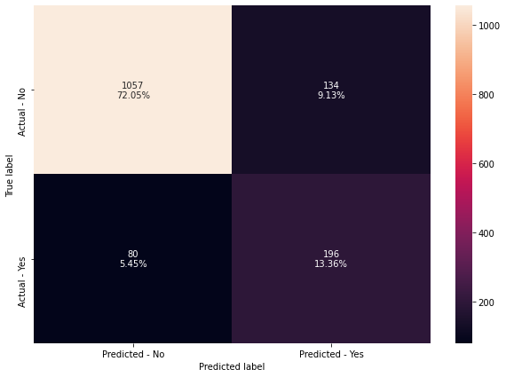

```python
make_confusion_matrix(bagging_dTree, y_test)
```

```python
# Recall on train and test
get_recall_score(bagging_dTree)
```

```
Recall on training set :  0.8586956521739131
Recall on test set :  0.7101449275362319
```

```python
# Choose the type of classifier.
bagging_dTree_tuned = BaggingClassifier(dTree_tuned, random_state=3)

# Grid of parameters to choose from
## add from article
parameters = {'max_samples': [0.7,0.8,0.9,1.0],
              'max_features': [0.7,0.8,0.9,1.0],
              'n_estimators' : [10,20,30,40,50],
             }

# Type of scoring used to compare parameter combinations
acc_scorer = metrics.make_scorer(metrics.recall_score)

# Run the grid search
grid_obj = GridSearchCV(bagging_dTree_tuned, parameters, scoring=acc_scorer,cv=5)
grid_obj = grid_obj.fit(X_train, y_train)

# Set the clf to the best combination of parameters
bagging_dTree_tuned = grid_obj.best_estimator_

# Fit the best algorithm to the data.
bagging_dTree_tuned.fit(X_train, y_train)
```

```
BaggingClassifier(base_estimator=DecisionTreeClassifier(ccp_alpha=0.0,
                                                        class_weight='balanced',
                                                        criterion='gini',
                                                        max_depth=10,
                                                        max_features=None,
                                                        max_leaf_nodes=64,
                                                        min_impurity_decrease=0.0,
                                                        min_impurity_split=None,
                                                        min_samples_leaf=8,
                                                        min_samples_split=2,
                                                        min_weight_fraction_leaf=0.0,
                                                        presort='deprecated',
                                                        random_state=3,
                                                        splitter='best'),
                  bootstrap=True, bootstrap_features=False, max_features=1.0,
                  max_samples=1.0, n_estimators=20, n_jobs=None,
                  oob_score=False, random_state=3, verbose=0, warm_start=False)
```

```python
# Recall on train and test
get_recall_score(bagging_dTree_tuned)
```

```
Recall on training set :  0.8633540372670807
Recall on test set :  0.7282608695652174
```

#### Bagging with logistic regression estimator

```python
bagging_lr = BaggingClassifier(LogisticRegression(class_weight='balanced', max_iter=1000), random_state=3)
bagging_lr.fit(X_train, y_train)
```

```
BaggingClassifier(base_estimator=LogisticRegression(C=1.0,
                                                    class_weight='balanced',
                                                    dual=False,
                                                    fit_intercept=True,
                                                    intercept_scaling=1,
                                                    l1_ratio=None,
                                                    max_iter=1000,
                                                    multi_class='auto',
                                                    n_jobs=None, penalty='l2',
                                                    random_state=None,
                                                    solver='lbfgs', tol=0.0001,
                                                    verbose=0,
                                                    warm_start=False),
                  bootstrap=True, bootstrap_features=False, max_features=1.0,
                  max_samples=1.0, n_estimators=10, n_jobs=None,
                  oob_score=False, random_state=3, verbose=0, warm_start=False)
```

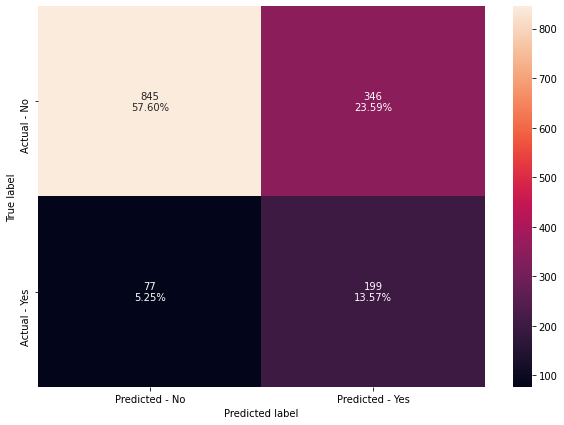

```python
make_confusion_matrix(bagging_lr, y_test)
```

```python
# Recall on train and test
get_recall_score(bagging_lr)
```

```
Recall on training set :  0.734472049689441
Recall on test set :  0.7210144927536232
```

### Random forest

```python
# Choose the type of classifier.
RF = RandomForestClassifier(random_state=3, max_depth=10, class_weight='balanced')

# Grid of parameters to choose from
## add from article
parameters = {"n_estimators": [50,100,200],
    "min_samples_leaf": [5,10],
    "max_features": [0.7, 0.8, 0.9, 1],
    "max_samples": [0.7, 0.8, 0.9, 1]
             }

# Type of scoring used to compare parameter combinations
acc_scorer = metrics.make_scorer(metrics.recall_score)

# Run the grid search
grid_obj = GridSearchCV(RF, parameters, scoring=acc_scorer,cv=5)
grid_obj = grid_obj.fit(X_train, y_train)

# Set the clf to the best combination of parameters
RF = grid_obj.best_estimator_

# Fit the best algorithm to the data.
RF.fit(X_train, y_train)
```

```
RandomForestClassifier(bootstrap=True, ccp_alpha=0.0, class_weight='balanced',
                       criterion='gini', max_depth=10, max_features=0.9,
                       max_leaf_nodes=None, max_samples=0.9,
                       min_impurity_decrease=0.0, min_impurity_split=None,
                       min_samples_leaf=10, min_samples_split=2,
                       min_weight_fraction_leaf=0.0, n_estimators=50,
                       n_jobs=None, oob_score=False, random_state=3, verbose=0,
                       warm_start=False)
```

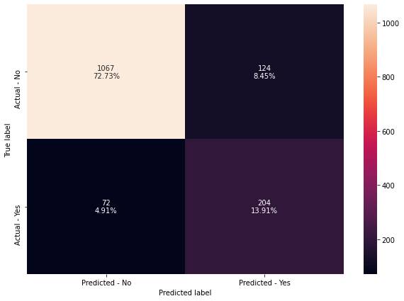

```python
make_confusion_matrix(RF, y_test)
```

```python
# Recall on train and test
get_recall_score(RF)
```

```
Recall on training set :  0.8944099378881988
Recall on test set :  0.7391304347826086
```

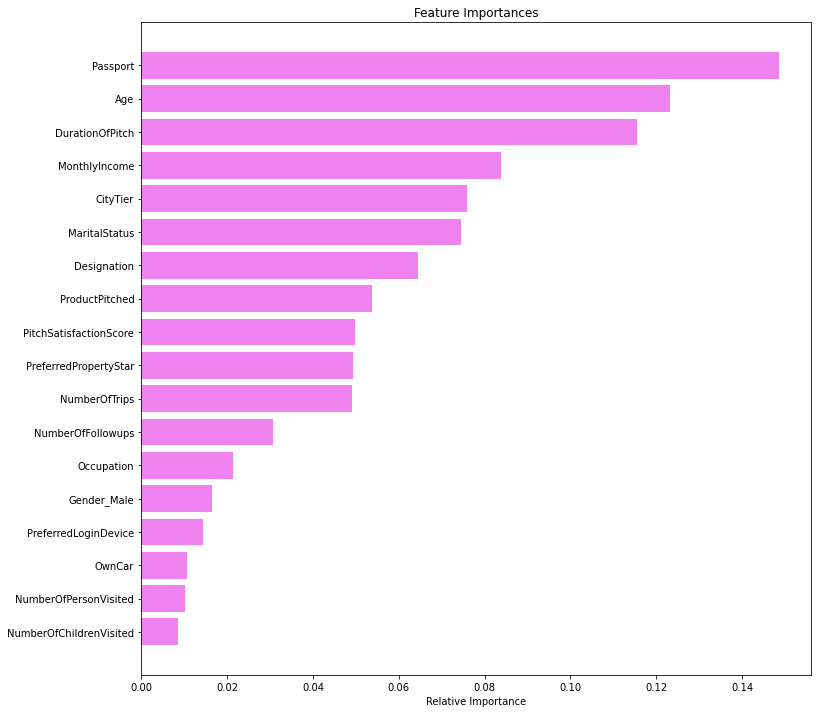

```python
importances = RF.feature_importances_
indices = np.argsort(importances)
feature_names=list(X.columns)

plt.figure(figsize=(12,12))
plt.title('Feature Importances')
plt.barh(range(len(indices)), importances[indices], color='violet', align='center')
plt.yticks(range(len(indices)), [feature_names[i] for i in indices])
plt.xlabel('Relative Importance')
plt.show()
```

## Model building - Boosting

Build Adaboost, gradient boost, xgboost and stacking classifier

### Adaboost classifier

```python
# Choose the type of classifier.
abc = AdaBoostClassifier(dTree_tuned, random_state=3)

# Grid of parameters to choose from
## add from article
parameters = {
    "n_estimators": [10, 20, 50, 100],
    "learning_rate": [0.1, 0.5, 1, 2]
}

# Type of scoring used to compare parameter combinations
acc_scorer = metrics.make_scorer(metrics.recall_score)

# Run the grid search
grid_obj = GridSearchCV(abc, parameters, scoring=acc_scorer,cv=5)
grid_obj = grid_obj.fit(X_train, y_train)

# Set the clf to the best combination of parameters
abc = grid_obj.best_estimator_

# Fit the best algorithm to the data.
abc.fit(X_train, y_train)
```

```
AdaBoostClassifier(algorithm='SAMME.R',
                   base_estimator=DecisionTreeClassifier(ccp_alpha=0.0,
                                                         class_weight='balanced',
                                                         criterion='gini',
                                                         max_depth=10,
                                                         max_features=None,
                                                         max_leaf_nodes=64,
                                                         min_impurity_decrease=0.0,
                                                         min_impurity_split=None,
                                                         min_samples_leaf=8,
                                                         min_samples_split=2,
                                                         min_weight_fraction_leaf=0.0,
                                                         presort='deprecated',
                                                         random_state=3,
                                                         splitter='best'),
                   learning_rate=0.5, n_estimators=10, random_state=3)
```

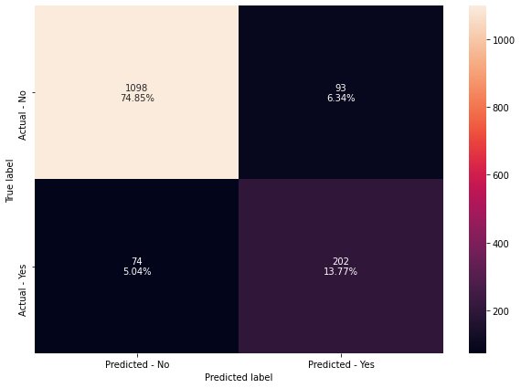

```python
make_confusion_matrix(abc, y_test)
```

```python
# Recall on train and test
get_recall_score(abc)
```

```
Recall on training set :  1.0
Recall on test set :  0.7318840579710145
```

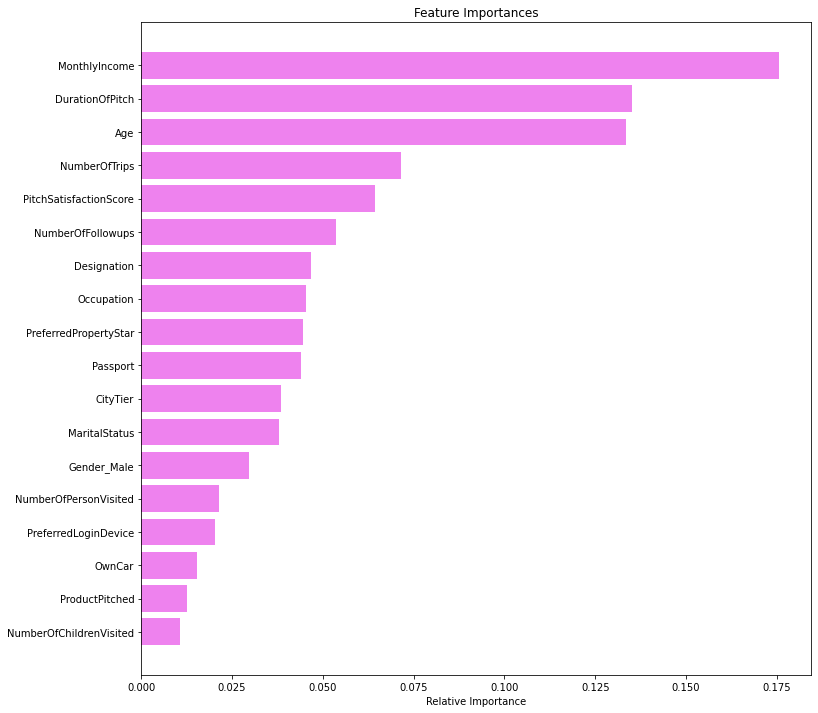

```python
importances = abc.feature_importances_
indices = np.argsort(importances)
feature_names=list(X.columns)

plt.figure(figsize=(12,12))
plt.title('Feature Importances')
plt.barh(range(len(indices)), importances[indices], color='violet', align='center')
plt.yticks(range(len(indices)), [feature_names[i] for i in indices])
plt.xlabel('Relative Importance')
plt.show()
```

### Gradient boosting classifier

```python
# Choose the type of classifier.
gbc = GradientBoostingClassifier(init=abc, random_state=3)

# Grid of parameters to choose from
## add from article
parameters = {
    "n_estimators": [100,150,200,250],
    "subsample":[0.8,0.9,1],
    "max_features":[0.7,0.8,0.9,1]
}

# Type of scoring used to compare parameter combinations
acc_scorer = metrics.make_scorer(metrics.recall_score)

# Run the grid search
grid_obj = GridSearchCV(gbc, parameters, scoring=acc_scorer,cv=5)
grid_obj = grid_obj.fit(X_train, y_train)

# Set the clf to the best combination of parameters
gbc = grid_obj.best_estimator_

# Fit the best algorithm to the data.
gbc.fit(X_train, y_train)
```

```
GradientBoostingClassifier(ccp_alpha=0.0, criterion='friedman_mse',
                           init=AdaBoostClassifier(algorithm='SAMME.R',
                                                   base_estimator=DecisionTreeClassifier(ccp_alpha=0.0,
                                                                                         class_weight='balanced',
                                                                                         criterion='gini',
                                                                                         max_depth=10,
                                                                                         max_features=None,
                                                                                         max_leaf_nodes=64,
                                                                                         min_impurity_decrease=0.0,
                                                                                         min_impurity_split=None,
                                                                                         min_samples_leaf=8,
                                                                                         min_samples_split=2,
                                                                                         min_weigh...
                           learning_rate=0.1, loss='deviance', max_depth=3,
                           max_features=0.8, max_leaf_nodes=None,
                           min_impurity_decrease=0.0, min_impurity_split=None,
                           min_samples_leaf=1, min_samples_split=2,
                           min_weight_fraction_leaf=0.0, n_estimators=200,
                           n_iter_no_change=None, presort='deprecated',
                           random_state=3, subsample=0.9, tol=0.0001,
                           validation_fraction=0.1, verbose=0,
                           warm_start=False)
```

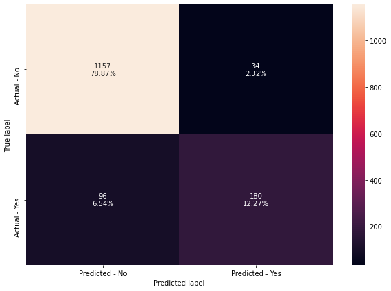

```python
make_confusion_matrix(gbc, y_test)
```

```python
# Recall on train and test
get_recall_score(gbc)
```

```
Recall on training set :  0.967391304347826
Recall on test set :  0.6521739130434783
```

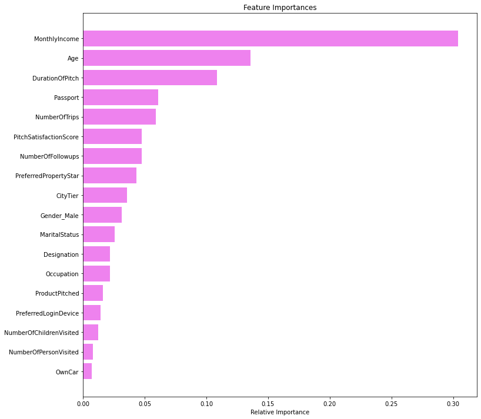

```python
importances = gbc.feature_importances_
indices = np.argsort(importances)
feature_names=list(X.columns)

plt.figure(figsize=(12,12))
plt.title('Feature Importances')
plt.barh(range(len(indices)), importances[indices], color='violet', align='center')
plt.yticks(range(len(indices)), [feature_names[i] for i in indices])
plt.xlabel('Relative Importance')
plt.show()
```

### XGBoost Classifier

```python
xgb = XGBClassifier(random_state=3, max_depth=20, colsample_bytree= 0.9, scale_pos_weight=100)
xgb.fit(X_train,y_train)
```

```
XGBClassifier(base_score=0.5, booster='gbtree', colsample_bylevel=1,
              colsample_bynode=1, colsample_bytree=0.9, gamma=0, gpu_id=-1,
              importance_type='gain', interaction_constraints='',
              learning_rate=0.300000012, max_delta_step=0, max_depth=20,
              min_child_weight=1, missing=nan, monotone_constraints='()',
              n_estimators=100, n_jobs=0, num_parallel_tree=1,
              objective='binary:logistic', random_state=3, reg_alpha=0,
              reg_lambda=1, scale_pos_weight=100, subsample=1,
              tree_method='exact', validate_parameters=1, verbosity=None)
```

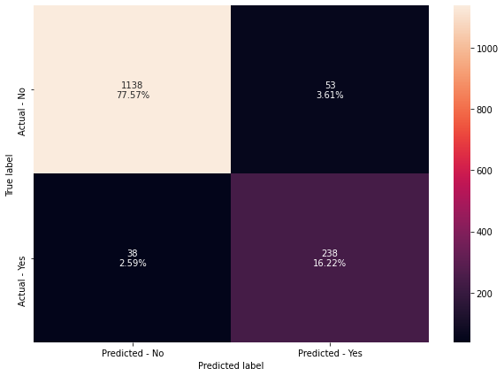

```python
make_confusion_matrix(xgb, y_test)
```

```python
# Recall on train and test
get_recall_score(xgb)
```

```
Recall on training set :  1.0
Recall on test set :  0.8623188405797102
```

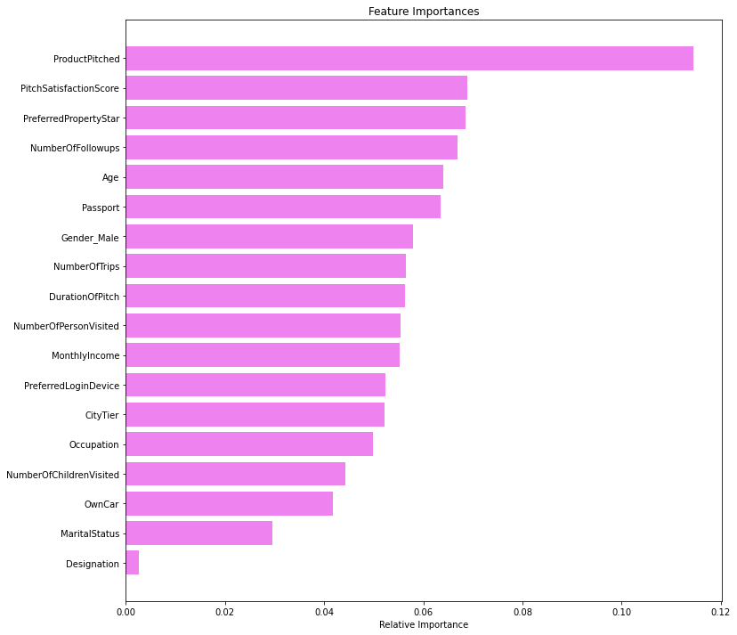

```python
importances = xgb.feature_importances_
indices = np.argsort(importances)
feature_names=list(X.columns)

plt.figure(figsize=(12,12))
plt.title('Feature Importances')
plt.barh(range(len(indices)), importances[indices], color='violet', align='center')
plt.yticks(range(len(indices)), [feature_names[i] for i in indices])
plt.xlabel('Relative Importance')
plt.show()
```

### Stacking model

```python
estimators=[('Decision Tree', dTree_pruned),('Random forest', RF),('Ada boost', abc)]
final_estimator=XGBClassifier(random_state=3, max_depth=1, scale_pos_weight=5)
```

```python
stacking=StackingClassifier(estimators=estimators, final_estimator=final_estimator,cv=5)
stacking.fit(X_train,y_train)
```

```
StackingClassifier(cv=5,
                   estimators=[('Decision Tree',
                                DecisionTreeClassifier(ccp_alpha=0.001272418548876897,
                                                       class_weight='balanced',
                                                       criterion='gini',
                                                       max_depth=None,
                                                       max_features=None,
                                                       max_leaf_nodes=None,
                                                       min_impurity_decrease=0.0,
                                                       min_impurity_split=None,
                                                       min_samples_leaf=1,
                                                       min_samples_split=2,
                                                       min_weight_fraction_leaf=0.0,
                                                       presort='deprecated',
                                                       random_stat...
                                                 max_depth=1,
                                                 min_child_weight=None,
                                                 missing=nan,
                                                 monotone_constraints=None,
                                                 n_estimators=100, n_jobs=None,
                                                 num_parallel_tree=None,
                                                 objective='binary:logistic',
                                                 random_state=3, reg_alpha=None,
                                                 reg_lambda=None,
                                                 scale_pos_weight=5,
                                                 subsample=None,
                                                 tree_method=None,
                                                 validate_parameters=None,
                                                 verbosity=None),
                   n_jobs=None, passthrough=False, stack_method='auto',
                   verbose=0)
```

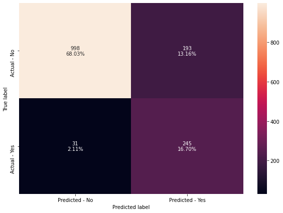

```python
make_confusion_matrix(stacking, y_test)
```

```python
# Recall on train and test
get_recall_score(stacking)
```

```
Recall on training set :  0.9984472049689441
Recall on test set :  0.8876811594202898
```

## Comparing models performance

```python
# defining list of models
models = [dTree, dTree_tuned, dTree_pruned, bagging_dTree, bagging_dTree_tuned, bagging_lr, RF, abc, gbc, xgb, stacking]

# defining empty lists to add train and test results
recall_train = []
recall_test = []

# looping through all the models to get the recall scores
for model in models:
    j = get_recall_score(model,False)
    recall_train.append(np.round(j[0],3))
    recall_test.append(np.round(j[1],3))
```

```python
comparison_frame = pd.DataFrame({'Model':['Decision tree without tuning','Decision tree with hyperparameter tuning',
                                        'Decision tree with pruning', 'Bagging Decision tree', 'Tuned Bagging Decision tree', 'Bagging Logistic Regression',
                                          'Random Forest', 'Ada Boost', 'Gradient Boosting', 'XG Boost', 'Stacking Classifier'],
                                          'Train_Recall':recall_train,'Test_Recall':recall_test})
comparison_frame
```

|  | Model | Train_Recall | Test_Recall |
| --- | --- | --- | --- |
| 0 | Decision tree without tuning | 1.000 | 0.739 |
| 1 | Decision tree with hyperparameter tuning | 0.915 | 0.808 |
| 2 | Decision tree with pruning | 0.960 | 0.826 |
| 3 | Bagging Decision tree | 0.859 | 0.710 |
| 4 | Tuned Bagging Decision tree | 0.863 | 0.728 |
| 5 | Bagging Logistic Regression | 0.734 | 0.721 |
| 6 | Random Forest | 0.894 | 0.739 |
| 7 | Ada Boost | 1.000 | 0.732 |
| 8 | Gradient Boosting | 0.967 | 0.652 |
| 9 | XG Boost | 1.000 | 0.862 |
| 10 | Stacking Classifier | 0.998 | 0.888 |

- 11 kind of machine learning models have been tested for purchase prediction including: decision trees, bagging classifiers (decision tree and logistic regression), random forest, ada boost, gradient boosting, XG boost and stacking classifiers.
- Models performance has been evaluated based on recall with the best performance achieved with a Stacking Classifier (88.8% of recall on test set)

## Business recommendations

- It is recommended to modify the marketing strategy in order to target younger and single customers.
- Customers owning already a passport are alson more likely to purchase the package.
- The multi and standard packages are among the most popular. Less focus should be put on pitching the super deluxe product.
- There is no real difference between men and women in terms of likelihood of purchasing the product.